# Example Report Template for a Data Analysis Project

Author

Elle Adams, Nalany Richardson

**Authors**

- Elle Adams$^{1, *}$ ,
- Nalany Richardson$^{1, *}$

**Author affiliations**

1. College of Public Health, University of Georgia, Athens, GA, USA.

$*$ These authors contributed equally to this work.

$\dagger$ Disclaimer: The opinions expressed in this article are the author’s own and don’t reflect their employer.

# 1 Summary/Abstract

This project was completed as part of week 3 of MADA 2026 at UGA in practice in working with collaborators, using Positron, and using GitHub. The initial code was cloned from a template provided by Dr. Handel, to which additional data on eye color and shoe size were added and analysis was performed on them to see the relationships with existing data. The final product is a very basic analysis and will be uploaded to the portfolio website of Elle Adams.

# 2 Introduction

## 2.1 General Background Information

The MADA course is a workload-intensive, asynchronous graduate-level course at UGA and this exercise occured in the third week of the course.

## 2.3 Questions/Hypotheses to be addressed

*The research question in this instance was to see how well we could could collaborate in our groups and follow the steps of a simple data analysis.

# 3 Methods

Expanded methods can be found on the MADA course website. Part one consisted of Elle Adams cloning the data-analysis-template to her GitHub, then local machine, and adding the columns Eye Color and Shoe Size and corresponding data. The changes were then pushed back to the GitHub repository, where Nalany Richardson was added as a collaborator. Nalany then performed part two, which included cloning the repository onto her own local machine and completing eye-height boxplot and size-weight-scatterplot. The changes were then pushed back to the GitHub repository. Elle then performed part three, which involved pulling Nalany’s changes to her local machine, creating resulttable3 and updating the report, before pushing the changes to GitHub and uploading the report to another repository containing the code for Elle Adams’ portfolio website.

## 3.1 Data import and cleaning

The data used in this siple analysis were provided in the data-analysis template of Dr. Handel on GitHub. There was already existing code to clean some of the input into a form that was logical and followed the parameters of the analysis. After adding two additional columns of data, not further cleaning was required.

## 3.2 Statistical analysis

The only real statistical analysis performed on the additional Eye Color and Shoe Size data what a linear regression with Height, which was already in the provided data, as the outcome and Eye Color and Shoe Size as the predictors.

# 4 Results

## 4.1 Basic analysis

This figure shows a boxplot comparing eye color and height.

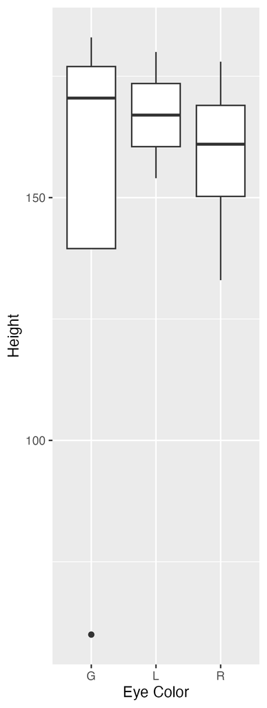

Figure 1: Boxplot comparing Eye Color and Height.

This figure shows a scatterplot comparing shoe size and weight.

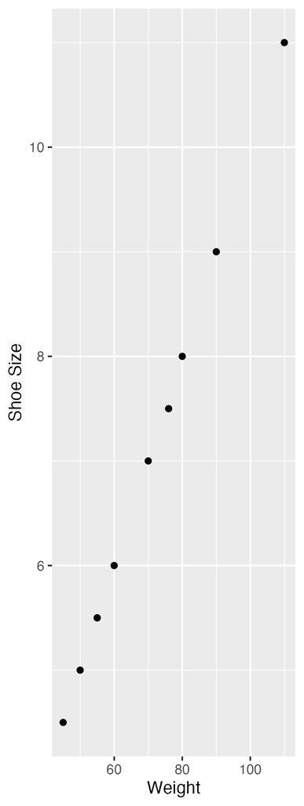

Figure 2: Scatterplot comparing Shoe Size and Weight

This figure shows a linear regression with height as the outcome and eye color and shoe size as the predictors.

Table 1: Linear model fit table.

| term | estimate | std.error | statistic | p.value |
| --- | --- | --- | --- | --- |
| (Intercept) | 116.736842 | 52.089336 | 2.2410891 | 0.0662478 |
| `Eye Color`L | 18.561404 | 36.886065 | 0.5032091 | 0.6327525 |
| `Eye Color`R | 2.495614 | 33.885641 | 0.0736481 | 0.9436843 |
| `Shoe Size` | 4.877193 | 7.932029 | 0.6148734 | 0.5612174 |

# 5 Discussion

## 5.1 Summary and Interpretation

After adding the additional data of Eye Color and Shoe Size, we were able to make comparisons to the existing values and Height and Weight, and learn more about using Positron and GitHub, particularly when working collaboratively. We also learned about the importance of documentation throughout your code.

## 5.2 Strengths and Limitations

The limitations of this analysis is that this assignment was in the third week of the course and the authors are still learning.

## 5.3 Conclusions

The main take-home messages are to make sure you explain what you’re doing to your data in each step and follow a READy workflow.

# 6 References